```python
#!/usr/bin/env python
```

# Demo: Time-Energy Calibration

This script illustrates the calibration of the time-energy correspondence. For many `TRINIDI` features we will need the time-of-flight (TOF) vector, `t_F` and time-of-arrival (TOA) vector `t_A`, which for the purposes of this example are assumed to be equal and simply referred to as time, `t`.

or

$$t = L \sqrt{ \frac{m}{2 E} } \; $$

where $m$ is the mass of the neutron.

In `TRINIDI` we assume that the time bins are equidistant and increasing i.e.

$$ t_i = i \Delta_t + t_0 \;$$

and that we have an estimate of the flight path length, $L$.

In this example we show (one way) to estimate `Δt` and `t_0` yielding the estimate of the vector `t`. This is done so that measured resonance peaks align with the corresponding resonances in the cross section dictionary, `D`.

```python
import numpy as np

import matplotlib.pyplot as plt

from trinidi import cross_section, simulate, util
```

First we generate a typical measurement spectrum `y_s`. The function below generates the data and prints out the ground truth values of `Δt` and `t_0`.

```python
def generate_measurement():
    r"""Generate measurements with `unknown` time calibration."""
    Δt = 0.30  # bin width [μs]
    t_0 = 72
    t_A = np.arange(t_0, 600, Δt)  # time-of-flight array [μs]
    print(f"Ground truth bin width:     {Δt = :.5f} μs")
    print(f"Ground truth starting time: {t_0 = :.2f} μs")

    t_F = t_A  # since R = Identity
    D = cross_section.XSDict(isotopes, t_F, flight_path_length)
    z = np.array([[0.005, 0.001]]).T

    ϕ, b, θ, α_1, α_2 = simulate.generate_spectra(t_A)
    y_s = α_1 * (ϕ.T * np.exp(-z.T @ D.values) + α_2 * b.T)
    return y_s.flatten()


flight_path_length = 10  # [m]
isotopes = ["U-235", "U-238"]  # isotopes in the sample
y_s = generate_measurement()
```

```
Ground truth bin width:     Δt = 0.30000 μs
Ground truth starting time: t_0 = 72.00 μs
```

The cross section dictionary `D` is generated and covers a time range that approximately covers the time region of the measurements.

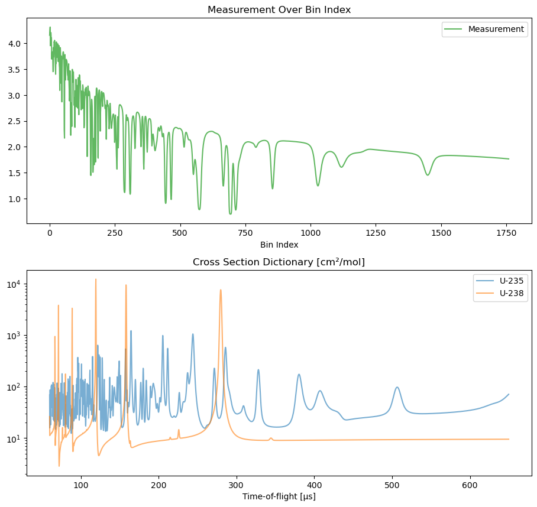

```python
# rough range of TOA to generate D
dictionary_t_A = np.arange(60, 650, 0.2)

D = cross_section.XSDict(isotopes, dictionary_t_A, flight_path_length)

fig, ax = plt.subplots(2, 1, figsize=[9, 9], sharex=False)
ax = np.atleast_1d(ax)
ax[0].plot(y_s, label="Measurement", alpha=0.75, color="tab:green")
ax[0].set_xlabel("Bin Index")
ax[0].set_title("Measurement Over Bin Index")
ax[0].legend()
D.plot(ax[1])
fig.suptitle("")
plt.tight_layout(pad=0.4, w_pad=0.5, h_pad=1.0, rect=(0, 0, 1, 0.95))
plt.show()
```

As you can see in the plot above, we only know the bin index for each measurement and we need to find a mapping to TOA.

Since the measurement contains a very distinct cross section profile we can find a few resonances that match the ones found in the plotted cross sections.

Below we manualy created a list of TOA bin indices and the corresponding TOAs in the cross section dictionary for a few prominent resonances.

```python
bin_index_list = [308.7, 692.9, 854.0, 1448.8]
time_list = [164.6, 279.9, 328.3, 506.6]
```

We plot the same lines again, highlighting the manually selected values.

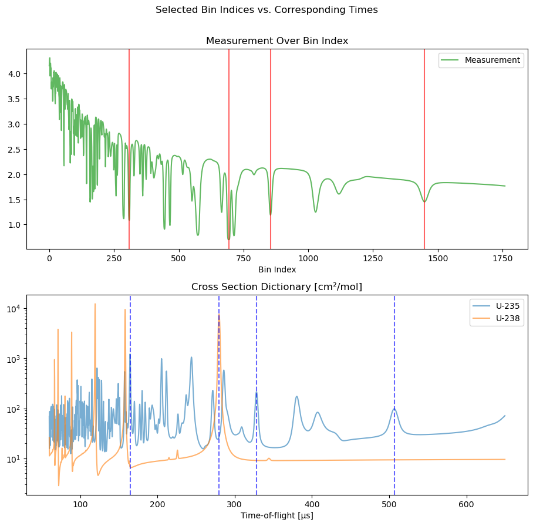

```python
fig, ax = plt.subplots(2, 1, figsize=[9, 9], sharex=False)
ax = np.atleast_1d(ax)
ax[0].plot(y_s, label="Measurement", alpha=0.75, color="tab:green")
for x in bin_index_list:
    ax[0].axvline(x=x, c="r", alpha=0.6)
ax[0].set_title("Measurement Over Bin Index")
ax[0].set_xlabel("Bin Index")
ax[0].legend()
D.plot(ax[1])
for x in time_list:
    ax[1].axvline(x=x, c="b", alpha=0.6, ls="--")
fig.suptitle("Selected Bin Indices vs. Corresponding Times")
plt.tight_layout(pad=0.4, w_pad=0.5, h_pad=1.0, rect=(0, 0, 1, 0.95))
plt.show()
```

Next, we use the following function to find an affine linear mapping from bin index to TOA. The resulting coefficients are the desired values of `Δt` and `t_0`.

```python
def bin_number_to_time(bin_index_list, time_list):
    r"""Find affine linear mapping from bin index to time.

    Args:
        bin_index_list: list of bin indices.
        time_list: list of corresponding times.

    Returns:
        The mapping.
    """
    # f(x) = m*x + b
    mb = np.polyfit(bin_index_list, time_list, 1)
    Δt = mb[0]
    t_0 = mb[1]
    return lambda i: Δt * i + t_0


f = bin_number_to_time(bin_index_list, time_list)
```

The resulting TOA vector is computed below using this mapping.

```python
N_A = y_s.size
t_A = f(np.arange(N_A))  # maps [0, 1, 2, ...] to [t_0, t_1, t_2, ...]

print(f"[{t_A[0] = :.2f}, {t_A[1] = :.2f}, {t_A[2] = :.2f}, ..., {t_A[-1] = :.2f}] μs")
```

```
[t_A[0] = 72.05, t_A[1] = 72.35, t_A[2] = 72.65, ..., t_A[-1] = 599.69] μs
```

Now that the `t_A` vector is known for the measurements, we can plot the measurements, `y_s`, and the dictionary, `D`, on the same x-axis to verify that the calibration was successful.

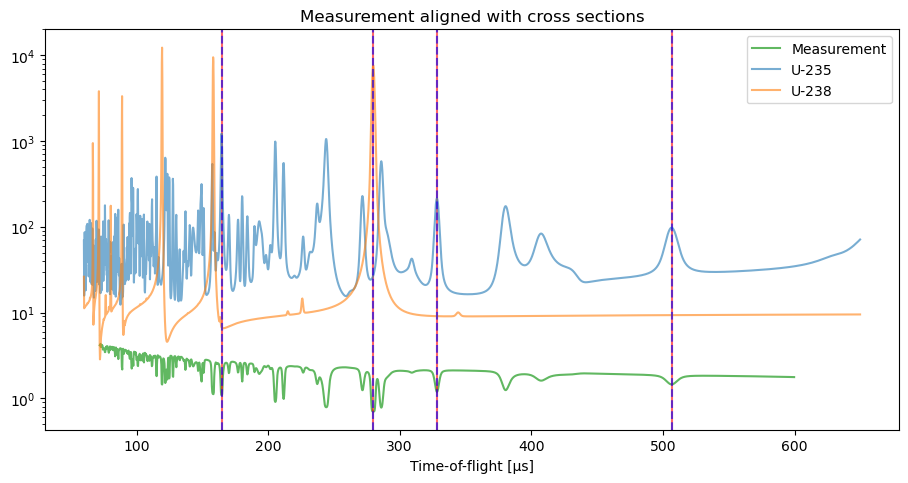

```python
fig, ax = plt.subplots(1, 1, figsize=[9, 5])
ax = np.atleast_1d(ax)
ax[0].plot(t_A, y_s, label="Measurement", alpha=0.75, color="tab:green")
for x in f(np.array(bin_index_list)):
    ax[0].axvline(x=x, c="r", alpha=0.6)
ax[0].set_xlabel("Time bin index")
ax[0].legend()
D.plot(ax[0])
for x in time_list:
    ax[0].axvline(x=x, c="b", alpha=0.6, ls="--")
ax[0].set_title("Measurement aligned with cross sections")
plt.tight_layout(pad=0.4, w_pad=0.5, h_pad=1.0, rect=(0, 0, 1, 0.95))
plt.show()
```

Additionally we can compute the values of `Δt` and `t_0`. Note that the estimated values are reltively close to the ground truth values that were printed above.

```python
t_0 = t_A[0]  # = f(0)
Δt = t_A[1] - t_A[0]  # = f(1) - f(0)
print(f"Estitated bin width:        {Δt = :.5f} μs")
print(f"Estitated starting time:    {t_0 = :.2f} μs")
```

```
Estitated bin width:        Δt = 0.29997 μs
Estitated starting time:    t_0 = 72.05 μs
```

If we are interested in the corresponding neutron energies we can use the built-in `time2energy` function to compute `E`. Note that by our convention, the t_F (and t_A) arrays are increasing which implies the energy array is decreasing.

```python
E = util.time2energy(t_A, flight_path_length)  # energy array [eV]

print(f"t_A = [{t_A[0]:.2f}, {t_A[1]:.2f}, ..., {t_A[-1]:.2f}] [μs]")
print(f"E   = [{E[0]:.2f}, {E[1]:.2f}, ..., {E[-1]:.2f}] [eV]")
```

```
t_A = [72.05, 72.35, ..., 599.69] [μs]
E   = [100.70, 99.87, ..., 1.45] [eV]
```